# Lab 7 - Inference on Means

## North Carolina Births

In 2004, the state of North Carolina released to the public a large data set containing information on births recorded in this state. This data set has been of interest to medical researchers who are studying the relation between habits and practices of expectant mothers and the birth of their children. We will work with a sample of observations from this data set. These 999 cases were chosen at random.

Let’s load the `nc` data set into our workspace. The data is in a file called `nc.csv`.

```r
# change working directory to the folder
# where the data is saved
nc = read.csv("nc.csv", header=T)
# attach dataset to workspace
attach(nc)
```

First, let’s calculate the mean and the standard deviation of babies’ weights in this sample as well as the sample size.

```r
xbar <- mean(weight)
s <- sd(weight)
n <- length(weight)
```

**Exercise 1:** Make a histogram of weight of the baby, `weight` variable, and describe the distribution of this variable.

Now we make a density histogram to use as the backdrop and use the `lines()` function to overlay a normal probability curve. The difference between a frequency histogram and a density histogram is that while in a frequency histogram the `heights` of the bars add up to the total number of observations, in a density histogram the `areas` of the bars add up to 1. The area of each bar can be calculated as simply the height $\times$ the width of the bar. Using a density histogram allows us to properly overlay a normal distribution curve over the histogram since the curve is a normal probability density function. Frequency and density histograms both display the same exact shape; they only differ in their y-axis. You can verify this by comparing the frequency histogram you constructed earlier and the density histogram created by the commands below.

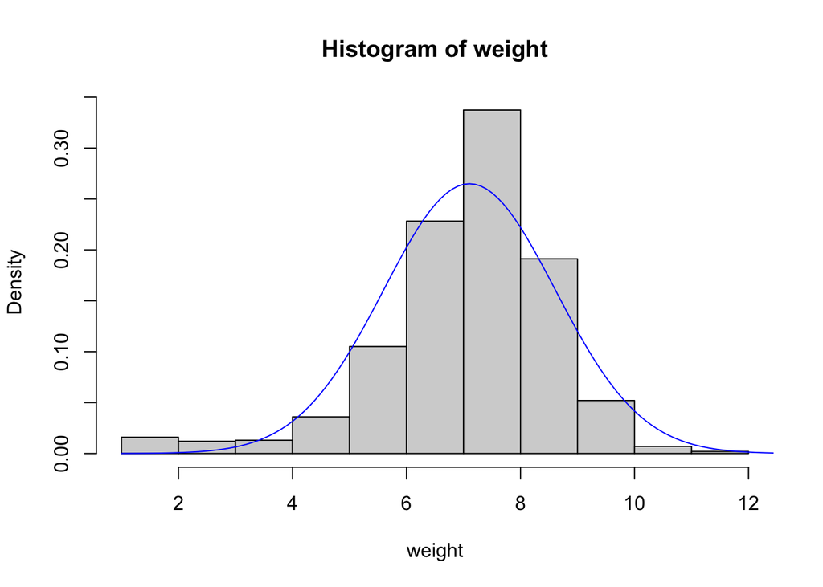

```r
# Plot histogram
hist(weight, probability = TRUE)
# Weights range
x = seq(1, 13, by=0.1)
# Compute density for x values
y = dnorm(x = x, mean = xbar, sd = s)
# Draw line on top of histogram
lines(x = x, y = y, col = "blue")
```

After plotting the density histogram with the first command, we create the x- and y-coordinates for the normal curve. We chose the `x` range as 1 to 13 in order to span the entire range of `weight`. To create `y`, we use `dnorm()` to calculate the density of each of those x-values in a distribution that is normal with mean `xbar` and standard deviation `s`. The final command draws a curve on the existing plot (the density histogram) by connecting each of the points specified by `x` and `y`.

Eyeballing the shape of the histogram is one way to determine if the data appear to be nearly normally distributed. A normal probability plot or Q-Q plot is also a good alternative approach to check for normality.

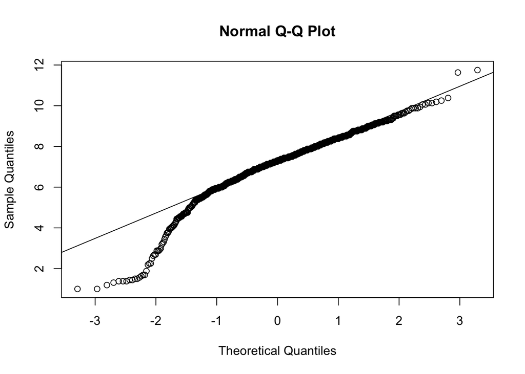

```r
qqnorm(weight)
qqline(weight)
```

**Exercise 2:** Based on these plots, does it appear that the data follow a nearly normal distribution?

Note that event though the Q-Q plot displays a deviation from normality, the sample size is large enough ($n=999 >30$) such that the results from the Central Limit Theorem still apply and we can proceed to perform inference on the parameters of interest.

## Confidence Intervals for a Mean

If we want to estimate the average weight of a baby at birth, we can use information from this sample to build a confidence interval for the true population parameter.

In this case the point estimate is the sample mean. The margin of error is always composed of two components, a critical value ($t^\star$ or $z^\star$) and a standard error multiplied together. The standard error for the sample mean can be calculated as $\frac{s}{\sqrt{n}}$. Let’s calculate that first.

```r
se <- s / sqrt(n)
```

Note that for $n=999$, the t-distribution – which is the exact distribution to use to calculate a confidence interval for the mean – is indistinguishable from the normal. By now, you probably know that $z^\star$ for a 95% confidence interval is 1.96. This value comes from the fact that $z = -1.96$ and $z = 1.96$ are the cutoff values for the middle 95% of a standard normal distribution. In other words, they are the cutoff points for the 2.5$^{th}$ percentile (in the lower end) and $2.5 + 95 = 97.5^{th}$ percentile (in the upper end). In order to get R to calculate this value for us, we use

```r
qnorm(0.975)
```

```
## [1] 1.959964
```

So if we wanted to calculate the critical value for a 98% confidence interval, we first need to realize that the middle 98% of the distribution will be bounded by the 1$^{st}$ and the 99$^{th}$ percentiles, and hence the critical value will be

```r
qnorm(0.99)
```

```
## [1] 2.326348
```

since the critical value is always positive.

**Exercise 3:** Verify that the critical values above are very similar to those obtained from the corresponding t-distribution.

Let’s get back to the calculation of the confidence interval. If we want to construct a 95% confidence interval we can set $z^\star$ to be

```r
zstar <- qnorm(0.975)
```

The margin of error is simply the product of $z^\star$ and the standard error

```r
me <- zstar * se
```

Then, the bounds of the confidence interval can be calculated as

```r
xbar - me
```

```
## [1] 7.011111
```

```r
xbar + me
```

```
## [1] 7.197838
```

**Exercise 4:** Interpret the confidence interval. Make sure to put it in context of the data.

## Hypothesis Testing for Means

In first world nations, the average birth weight of a full-term new born is approximately 7.5 pounds. Let’s see how the average weight of babies born in North Carolina compare to this value.

In order to do this we need to first subset our dataset to include only full-term babies. We’ll call this new data set `nc_ft`.

```r
nc_ft <- subset(nc, nc$premie == "full term")
```

You should see a new data set appear in your workspace which has 846 rows and 13 variables. Earlier we saw that there were 152 premature and 846 full term births, hence we know that there should be 846 cases (rows) in the new data set that we just created.

Let’s calculate the mean birth weight for the full term babies

```r
xbar = mean(nc_ft$weight)
boot_means <- replicate(5000, mean(sample(nc_ft$weight, replace = TRUE)))
```

**Exercise 5:** How would you expect the sample mean of birth weight to differ between the complete dataset (`nc`) and the subsetted dataset (`nc_ft`)?

**Solution** The mean birth rate from the complete data set (`nc`) should be slightly lower than the sample mean birth weight since in the subset data set (`nc_ft`) we excluded all of the data points that come from babies that were not full term at the time of birth. Since the average birth weight of a full-term new born is approximately 7.5 pounds and the data points that we removed include all babies that were not full term. These babies have weights that are likely below the average weight of 7.5 pounds meaning that the sample mean will be higher than if we did not create a subset.

**Exercise 6:** Write the hypotheses for testing if the average weight of full term babies born in North Carolina is different than 7.5 ounces.

To conduct the hypothesis test we need to first calculate a test statistic, a $z$-score, using the formula

$$z = \frac{\bar{x} - \mu}{SE}$$

```r
## xbar = mean(nc_ft$weight) from above ^^
mu <- 7.5
s <- sd(nc_ft$weight)
n <- length(nc_ft$weight)
se <- s / sqrt(n)
z <- (xbar - mu) / se
```

Calculating the p-value is a two step process: first find the tail area, and then multiply by two since the alternative hypothesis is two sided.

```r
tail <- pnorm(z, lower.tail = TRUE)
pval <- tail * 2
```

Note that we used `lower.tail = TRUE` since the $z$-score we obtained was negative. If we wanted to get the upper tail, which is often the case when we have a positive $z$-score, we would use `lower.tail = FALSE`.

**Exercise 8:** What is the conclusion of the hypothesis test? Make sure to to provide an interpretation in context.

**Solution** If p-value < α, reject H0, data provide evidence for HA If p-value > α, do not reject H0, data do not provide evidence for HA If µ0 is inside the CI ⇒ fail to reject H0. If µ0 is outside the CI ⇒ reject H0.

Since p-value=0.272 and is greater than 0.05 we fail to reject H0. The data dose not provide convincing evidence that the average weight of full term babies born in North Carolina is different than 7.5 pounds.

## More Practice

1. Using the original data set, `nc`, create a new data set called `nc_sm` that only contains information from smoker mothers. Then calculate the average weight gained by these mothers.

```r
nc_sm <- subset(nc, nc$habit == "smoker")
```

Note that the variable ‘gained’ contains missing values that will produce a value of `NA` (i.e. Not Available) in your calculations. To remove the missing values (after you create the `nc_sm` data set), define a new variable called `gain` using the following code :

```r
gain <- nc_sm$gained[is.na(nc_sm$gained)==F]
```

Use the `gain` variable you just created to perform all calculations.

2. Check if the assumptions and conditions necessary for inference on a mean are satisfied for this sample of smoker mothers.

**Solution** We need to check that the data is a random sample, independence, and the sampling distribution is approximately normal.

[output not shown]

```r
nc_sm <- subset(nc, nc$habit == "smoker")
gain <- nc_sm$gained[is.na(nc_sm$gained)==F]
xbar_sm <- mean(gain)
s_sm <- sd(gain)
n_sm <- length(gain)
boot_mean_sm <- replicate(5000, mean(sample(gain, replace = TRUE)))

xbar_sm
```

```
## [1] 31.92623
```

```r
print(boot_mean_sm[1:10])
```

```
##  [1] 32.60656 31.53279 33.20492 30.43443 35.01639 31.91803 32.09836 30.55738
##  [9] 32.50820 31.50000
```

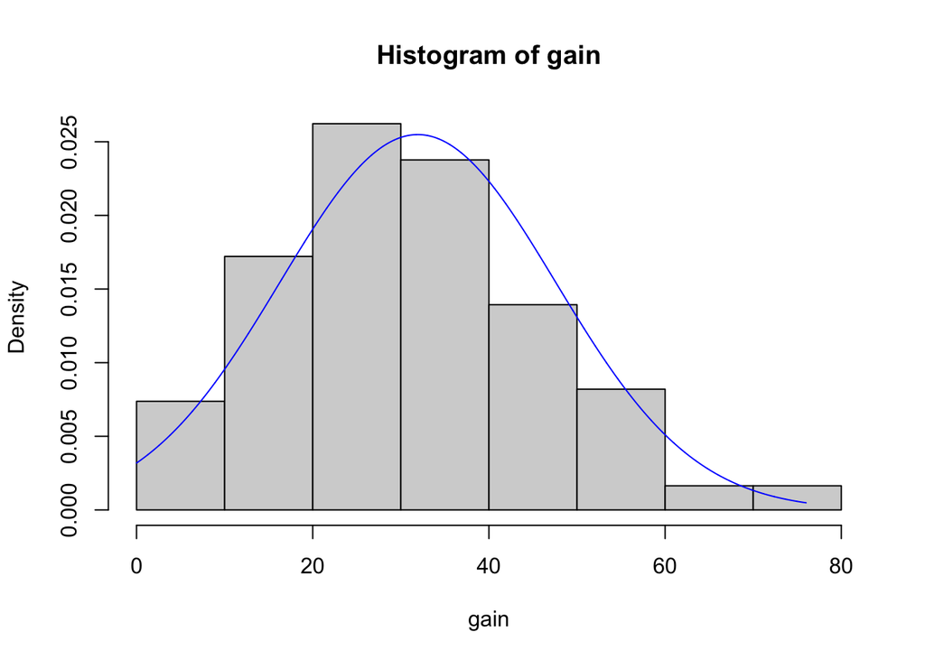

```r
hist(gain, probability = TRUE)
x_sm = seq(0, 76, by=.01)
y_sm = dnorm(x = x_sm, mean = mean(gain), sd = sd(gain))
lines(x = x_sm, y = y_sm, col = "blue")
```

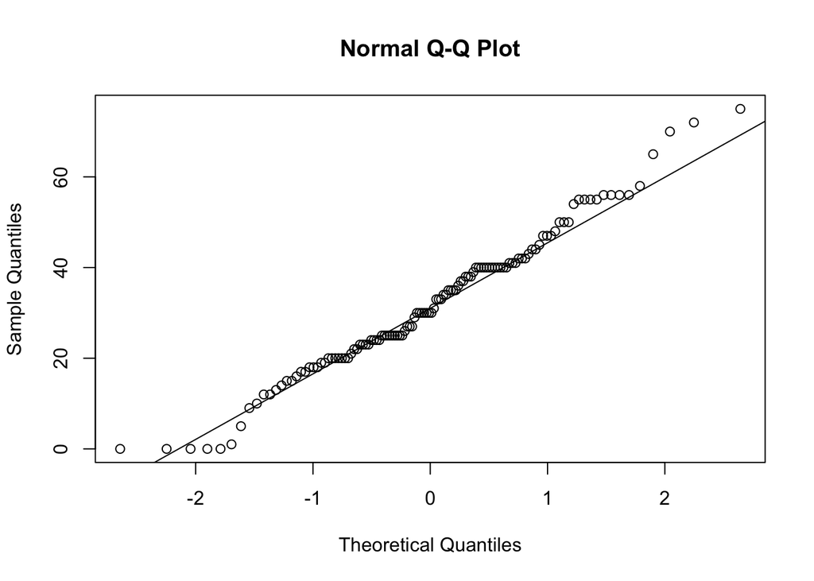

```r
qqnorm(gain)
qqline(gain)
```

3. Construct a 95% confidence interval for the average weight gained by smoker mothers and provide an interpretation for this interval in context.

Where the margin of error is always composed of the product of two components, a critical value (t⋆ or z⋆) and a standard error.

```r
se_smoker <- s_sm / sqrt(n_sm)
me_smoker <- zstar * se_smoker

# The bounds of the confidence interval can be calculated as
xbar_sm - me_smoker
```

```
## [1] 29.14897
```

```r
xbar_sm + me_smoker
```

```
## [1] 34.70349
```

4. Weight gain of roughly 30 pounds is considered normal. Conduct a hypothesis test to evaluate if the average weight gain of smoker mothers is different than 30 pounds. Make sure to interpret your conclusion in context of the question.

**Solution** The Null Hypothesis ($H_{0}$): The average weight gain of smoker mothers is equal to 30 pounds. Alternative Hypothesis ($H_{a}$): The average weight gain of smoker mothers is not equal to 30 pounds. To conduct the hypothesis test we need to first calculate a test statistic, a $z$-score, using the formula

$$z = \frac{\bar{x} - \mu}{SE}$$

```r
# Calculate the following:
# mu zero
# number of smokers
# standard deviation smokers

# xbar_sm <- mean(gain)   ## calculated above ^^
mu_sm <- 30
s_sm <- sd(gain)
n_sm <- length(gain)

se_sm <- s_sm / sqrt(n_sm)
se_sm
```

```
## [1] 1.416997
```

```r
z_sm <- (xbar_sm - mu_sm) / se_sm
z_sm
```

```
## [1] 1.359374
```

```r
pnorm(z_sm, lower.tail = FALSE)
```

```
## [1] 0.087014
```

```r
# tail <-pnorm(z_sm, lower.tail = FALSE)
# pval <- 2 * tail
# pval
```

5. Do the results of the confidence interval and hypothesis test agree with each other? Is this what you would expect or not? Explain.

**Solution** Yes the results of the two tail hypothesis test and the corresponding confidence interval will always agree; this is expected since they are two different perspectives on the same statistical question.

### Inference for proportions

Follow similar steps for the following exercise on inference for proportions i.e. check assumptions, show your calculations, state the hypothesis, and interpret your results in context.

6. Estimate the population proportion of premature births $p$ using a 95% confidence interval.

**Solution** Since the confidence interval is always of the form point estimate +/- ME. The margin of error (ME) is always composed of the product of a critical value (t⋆ or z⋆) and the standard error. The standard error is the standard deviation of the parameter of interest divided by the square root of the total number of samples.

CI = p_hat +/- ME = p_hat +/- z_star * SE = p_hat +/- z_star * s / sqrt(n) = p_hat +/- z_star * sd(param) / sqrt(n)

We will begin by creating a value to store the number of premature births and construct a 95% confidence interval.

```r
nc_premi <- subset(nc, nc$premie == "premie") # New subset only includes premature births
n_premi <- length(nc_premi$premie) # Count the number of premature births in the sample
n_total <- length(nc$premie) # Total number in sample

p_hat <- n_premi / n_total # the sample point estimate
q_hat <- 1 - p_hat # q = (1 - p)

# Since we are calculating a 95% CL, then calculate zstar
zstar <- qnorm(0.975) ## equals 1.959964
```

Next we can calculate the margin of error (ME) which is always composed of the product of a critical value (t⋆ or z⋆) and the standard error. The margin of error for a proportion is expressed as the following:

MoE = $({z}_{\frac{\alpha }{2}} (\sqrt{\frac{\hat{p}\hat{q}}{n}})$

where $\hat{q}\text{ = 1 - }\hat{p}$

Using this formula we can conduct the calculations substituting the values found above and the final 95% confidence interval.

```r
me_premature <- zstar * (sqrt((p_hat * q_hat)/n_total))

# # The bounds of the confidence interval can be calculated as
p_hat - me_premature
```

```
## [1] 0.1298799
```

```r
p_hat + me_premature
```

```
## [1] 0.1744244
```

We can conclude with 95% certainty that the proportion of premature births in the population is between 12.9% and 17.4%.

7. Calculate a 95% bootstrap confidence interval for the proportion of premature births. How does it compare to the interval in question 6?

```r
# # clean up the original data
# premie_clean = na.omit(nc$premie)
# np <- length(premie_clean)
#
# ## re-sample the data with replacement 10,000 times and remove all N/A values.
# boot_premi <- replicate(10000, sample(nc$premie[is.na(nc$premie)==F], size = np, replace = TRUE))
#
# ## For each sample, calculate the proportion of premature births. This creates a distribution of sample proportions (the bootstrap distribution).


# Function to re-sample and calculate the proportion
# boot_prop <- function(data) {
#   boot_sample <- data[sample(nrow(data), replace = TRUE), ]
#   n_premie_boot <- sum(boot_sample$premie == "premie", na.rm = TRUE)
#   n_total_boot <- sum(!is.na(boot_sample$premie))
#   return(n_premie_boot / n_total_boot)
# }
boot_prop <- function(clean_data) {
  # Resample the data vector with replacement
  boot_sample <- sample(clean_data, replace = TRUE)

  # Calculate the proportion of "premie" in the resampled vector
  n_premie_boot <- sum(boot_sample == "premie", na.rm = TRUE)
  n_total_boot <- sum(!is.na(boot_sample))

  return(n_premie_boot / n_total_boot)
}


# clean up the original data
premie_clean = na.omit(nc$premie)

# Perform the bootstrap re-sampling
boot_distribution <- replicate(10000, boot_prop(premie_clean))
# boot_distribution <- replicate(10000, boot_prop(nc))

# Calculate and print the 95% percentile bootstrap confidence interval
ci_bootstrap <- quantile(boot_distribution, c(0.025, 0.975))

cat("Bootstrap CI:", round(ci_bootstrap, 6))
```

```
## Bootstrap CI: 0.130261 0.175351
```

**Solution** The 95% bootstrap confidence interval for the proportion of premature births is approximately (0.13, 0.175).

**Comparison** The bootstrap confidence interval (approximately (0.1303, 0.1754)) is very similar to the traditional normal approximation interval (0.1298799 and 0.1744244). The minor differences are negligible, which is expected because the sample size is large enough (n=999) for the normal approximation to be accurate.

8. In the United States, the proportion of live births that are premature is approximately 10%. Test the hypothesis that the proportion of premature births in is greater than 10%.

**Solution** First state the null and alternative hypothesis:

Null (h_0): The proportion of premature births is equal to 10% where p=0.10 Alternative (h_a): The proportion of premature births is greater than 10% where p>0.10 We will use a significance level of 0.05 in the calculations below.

Next collect data from our sample of nc births.

```r
# nc_premi_ht <- subset(nc, nc$premie == "premie") # New subset only includes premature births
# n_premi_ht <- length(nc_premi_ht$premie) # Count the number of premature births in the sample
# n_premi_ht
# n_total <- length(nc$premie) # Total number in sample
# n_total
#
#
# ## calculate the sample proportion
# p_hat_ht <- n_premi_ht / n_total
# p_hat_ht
#
# ## Conduct one proportion z-test
# ## Use the test statistic z = (p_hat_ht - p_0) / (sqrt((p_0 * (1-p_0)) / n_births))
# p_0 <- .10
# z_test <- (p_hat_ht - p_0) / (sqrt((p_0 * (1-p_0)) / n_births))
# z_test
# ## Generate the p-value, find the probability of getting a z-score of z_test or higher using a z-table or calculate it with R.


####################################################################################################
# Define sample data and hypothesis parameters
nc_premi_ht <- subset(nc, nc$premie == "premie") # New subset only includes premature births
n_premi_ht <- length(nc_premi_ht$premie) # Count the number of premature births in the sample
n_total <- length(nc$premie) # Total number in sample

p0 <- 0.10         # Hypothesized population proportion (0.10 or 10%)
alpha <- 0.05      # Significance level

# Calculate the sample proportion
p_hat <- n_premi_ht / n_total

# Calculate the standard error under the null hypothesis (SE0)
# Formula: sqrt(p0 * (1 - p0) / n_total)
se_0 <- sqrt(p0 * (1 - p0) / n_total)

# Calculate the Z-test statistic
# Formula: (p_hat - p0) / se_0
z_score <- (p_hat - p0) / se_0

# Calculate the p-value for a one-sided (greater than) test
# We use the standard normal cumulative distribution function pnorm()
# Since we want the area to the RIGHT (greater than), we use lower.tail = FALSE
p_value <- pnorm(z_score, lower.tail = FALSE)

# Print the results
cat("Sample Proportion (p_hat):", round(p_hat, 4), "\n")
```

```
## Sample Proportion (p_hat): 0.1522
```

```r
cat("Z-Test Statistic:", round(z_score, 4), "\n")
```

```
## Z-Test Statistic: 5.4946
```

```r
cat("P-value:", format(p_value, scientific = TRUE, digits = 4), "\n")
```

```
## P-value: 1.958e-08
```

```r
p_hat
```

```
## [1] 0.1521522
```

```r
z_score
```

```
## [1] 5.49457
```

```r
p_value
```

```
## [1] 1.958316e-08
```

If the p-value is less than a significance level of 0.05, we reject the null hypothesis and conclude that the proportion of premature births is significantly greater than 10%.

But if the p-value is greater than the significance level of 0.05%, we will fail to reject the null hypothesis.

**Reject the null** In this case, the p-value is less than the significance level, we reject the null hypothesis and conclude that the proportion of premature births in North Carolina is greater than 10%.